# 港.股.迷.惑.行.为.大.赏

## 原地静止组：交易量垫底

按平均月交易量排序垫底的10支股票及月交易量：

```r
bottom10_vol <- order(mean_volume)[1:10]
data.frame(
  symbol=all_symbols[bottom10_vol],
  mean.vol=mean_volume[bottom10_vol])
```

| symbol | mean.vol |
| --- | --- |
| 02916.HK | 0.00000 |
| 09813.HK | 23.08466 |
| 09125.HK | 26.54867 |
| 09011.HK | 27.31069 |
| 09078.HK | 39.63768 |
| 09829.HK | 61.59292 |
| 09077.HK | 80.39104 |
| 09022.HK | 254.46318 |
| 09069.HK | 320.10582 |
| 09167.HK | 380.32118 |

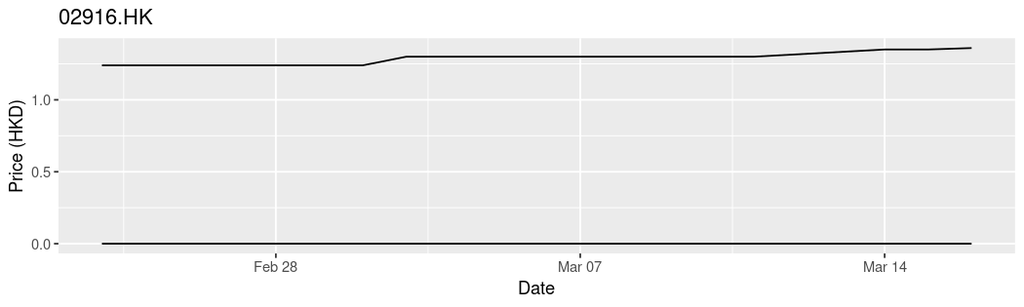

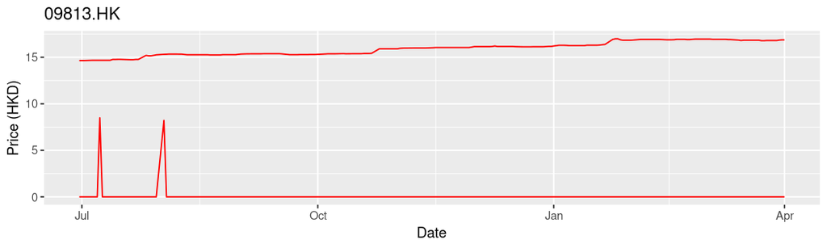

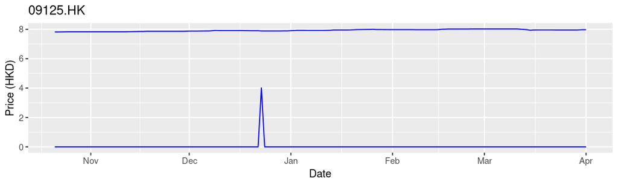

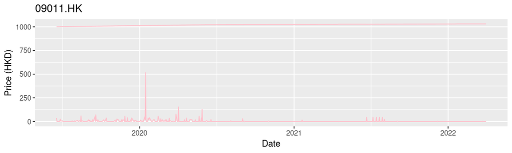

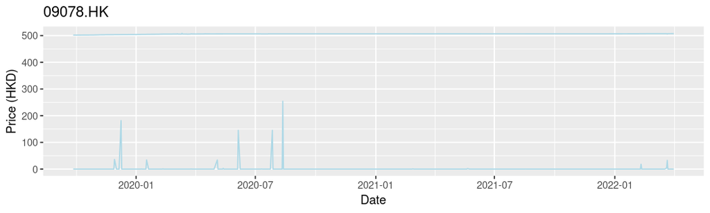

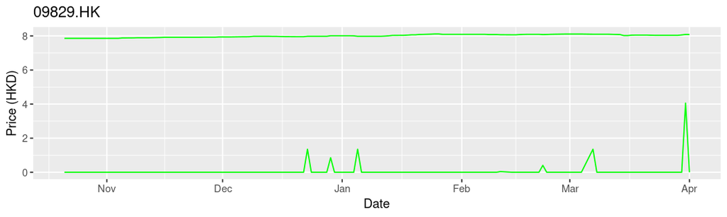

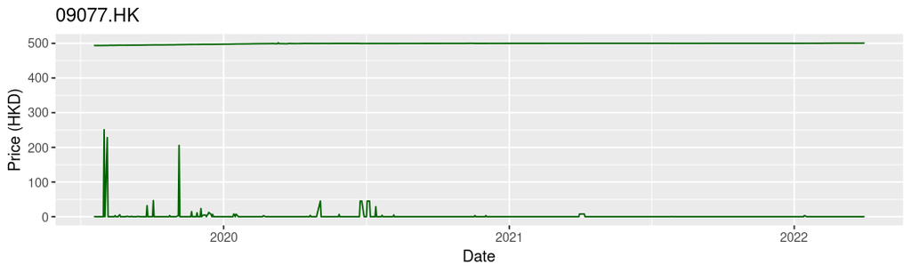

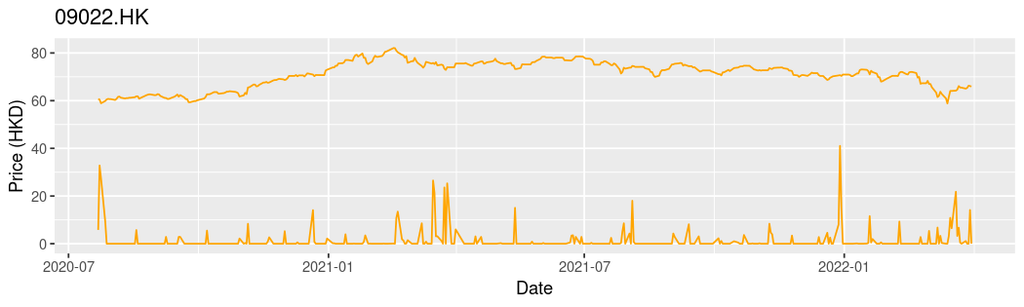

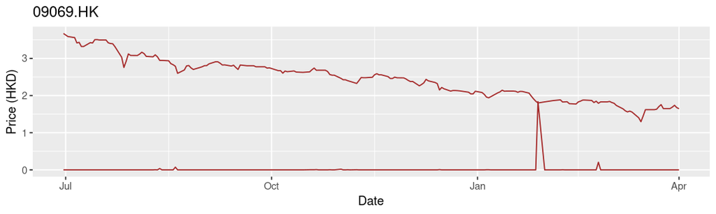

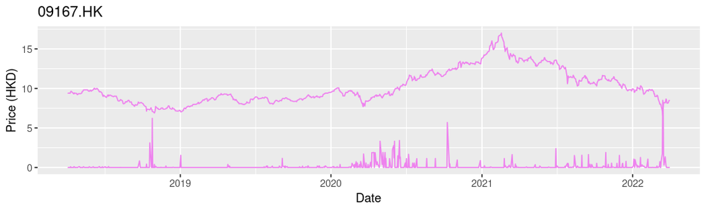

```r
# 画图
col10 <- c("black","red","blue","pink","lightblue",
           "green","darkgreen","orange","brown","violet")
c <- 1
for (i in bottom10_vol){
  maxvol <- max(stocks_all[[i]]$volume)
  if (maxvol<1e-10) { maxvol <- 1 }
  amp <- 0.5*max(stocks_all[[i]]$close)/maxvol
  p <- ggplot() +
       geom_line(data=stocks_all[[i]],aes(x=date,y=close),color=col10[[c]]) +
       geom_line(data=stocks_all[[i]],aes(x=date,y=amp*volume),color=col10[[c]]) +
       labs(x="Date", y="Price (HKD)") +
       ggtitle(all_symbols[[i]])
  print(p)
  c <- c+1
}
```

按平均月交易量排序垫底的11-20名：

```r
bottom11_20_vol <- order(mean_volume)[11:20]
data.frame(
  symbol=all_symbols[bottom11_20_vol],
  mean.vol=mean_volume[bottom11_20_vol])
```

| symbol | mean.vol |
| --- | --- |
| 09096.HK | 387.9641 |
| 09081.HK | 655.0144 |
| 09810.HK | 829.5039 |
| 09001.HK | 906.8884 |
| 02917.HK | 1066.6667 |
| 09186.HK | 1074.8473 |
| 09834.HK | 1119.2831 |
| 00158.HK | 1145.8080 |
| 00277.HK | 1293.3414 |
| 09181.HK | 1342.9125 |

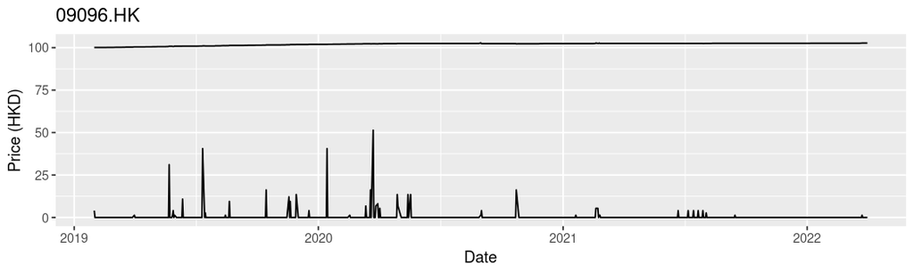

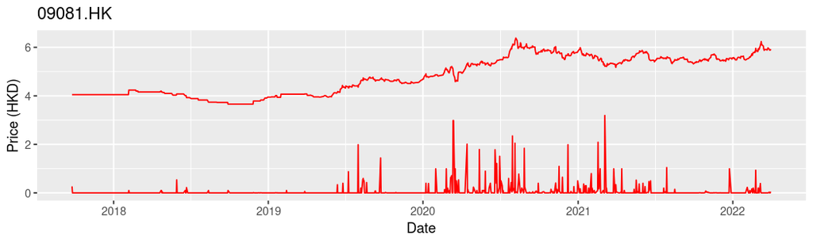

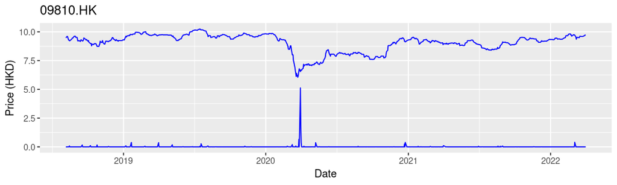

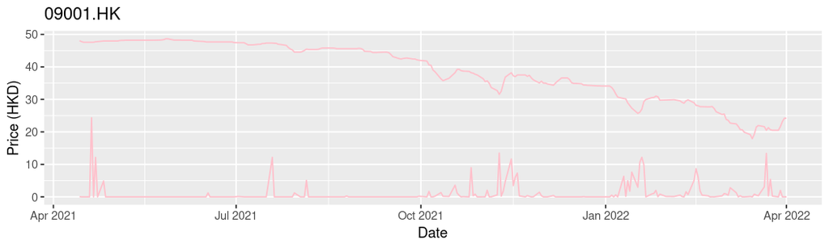

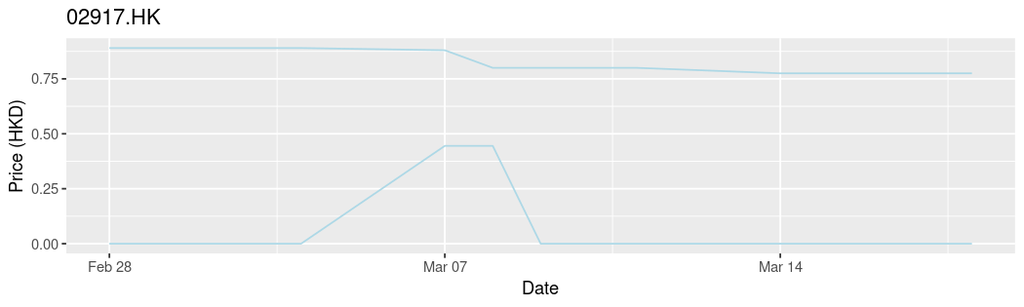

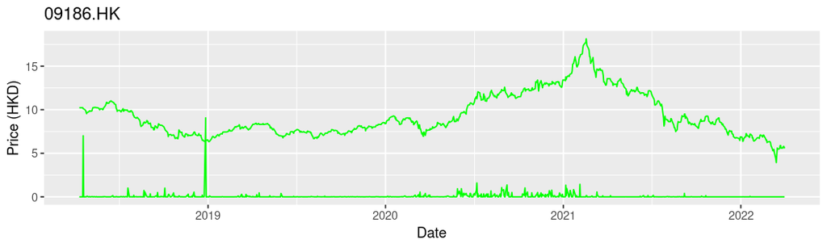

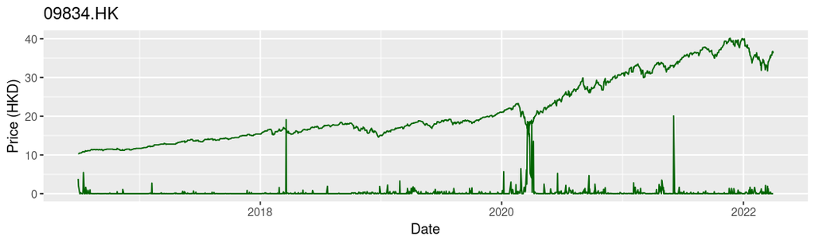

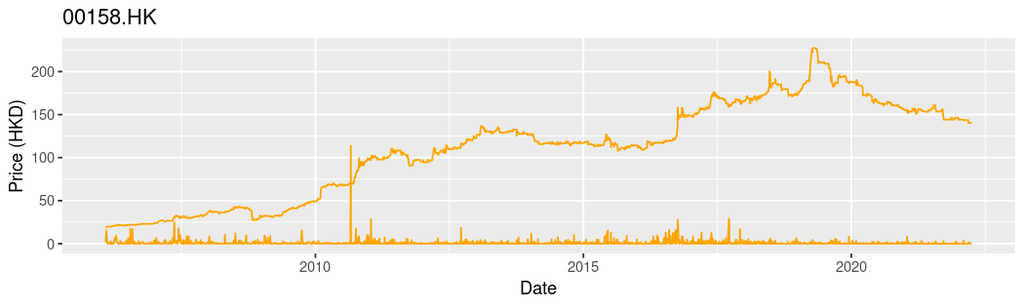

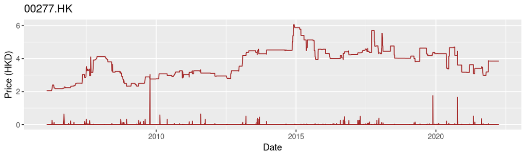

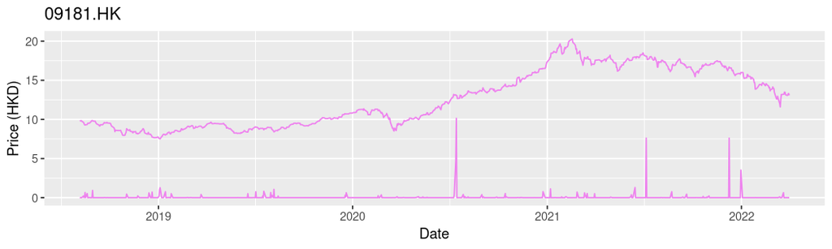

```r
# 画图
col10 <- c("black","red","blue","pink","lightblue",
           "green","darkgreen","orange","brown","violet")
c <- 1
for (i in bottom11_20_vol){
  maxvol <- max(stocks_all[[i]]$volume)
  if (maxvol<1e-10) { maxvol <- 1 }
  amp <- 0.5*max(stocks_all[[i]]$close)/maxvol
  p <- ggplot() +
       geom_line(data=stocks_all[[i]],aes(x=date,y=close),color=col10[[c]]) +
       geom_line(data=stocks_all[[i]],aes(x=date,y=amp*volume),color=col10[[c]]) +
       labs(x="Date", y="Price (HKD)") +
       ggtitle(all_symbols[[i]])
  print(p)
  c <- c+1
}
```

按平均月交易量排序垫底的21-30名：

```r
bottom21_30_vol <- order(mean_volume)[21:30]
data.frame(
  symbol=all_symbols[bottom21_30_vol],
  mean.vol=mean_volume[bottom21_30_vol])
```

| symbol | mean.vol |
| --- | --- |
| 09086.HK | 1649.153 |
| 09072.HK | 2032.318 |
| 00377.HK | 2084.478 |
| 00287.HK | 2377.341 |
| 09091.HK | 2502.315 |
| 09803.HK | 2511.628 |
| 09804.HK | 2533.433 |
| 01570.HK | 2719.956 |
| 00247.HK | 3237.709 |
| 09846.HK | 3526.961 |

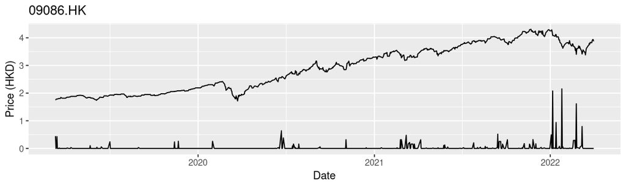

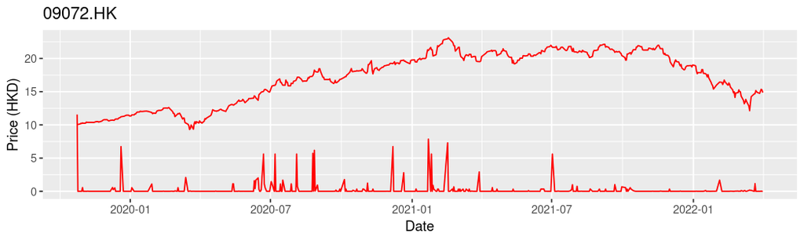

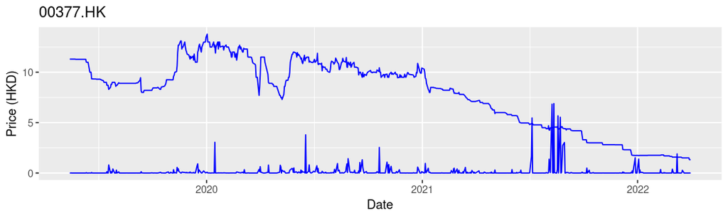

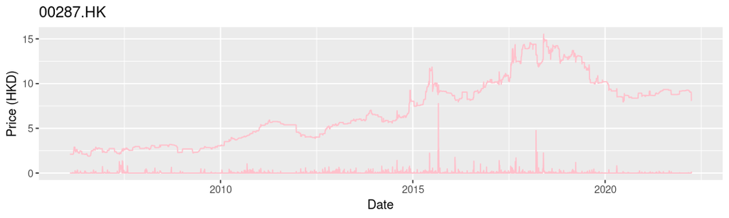

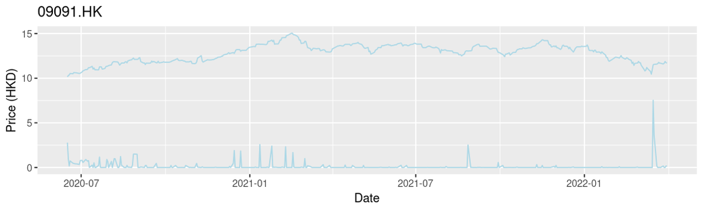

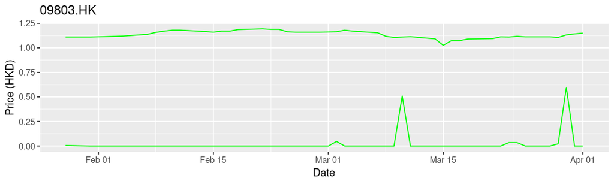

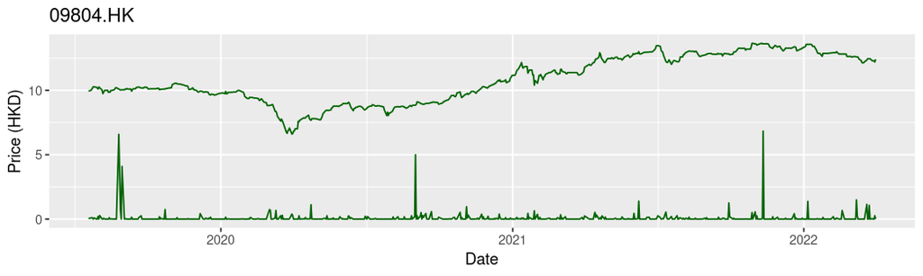

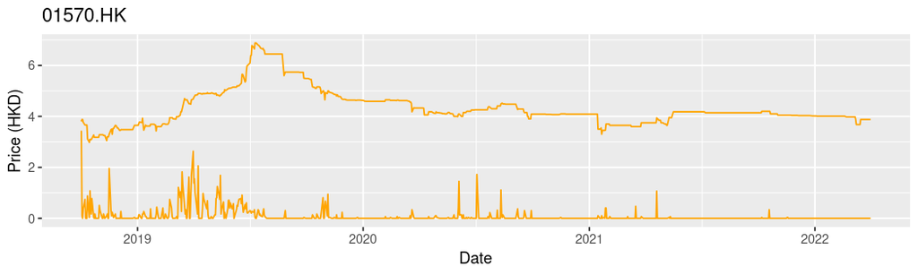

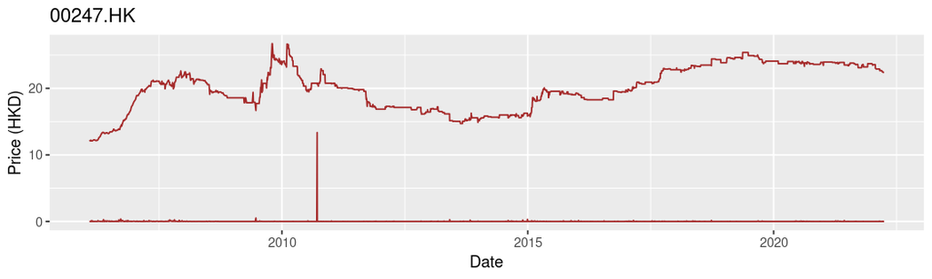

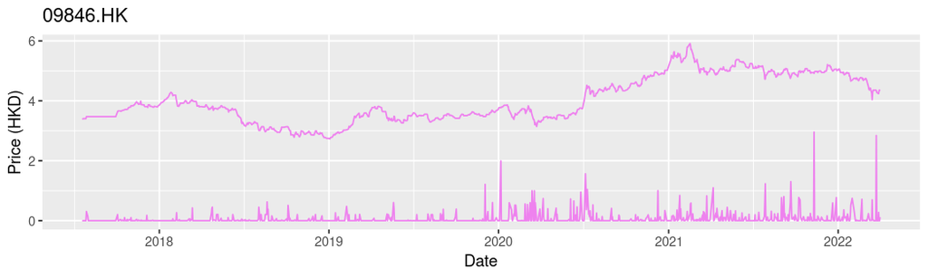

```r
# 画图
col10 <- c("black","red","blue","pink","lightblue",
           "green","darkgreen","orange","brown","violet")
c <- 1
for (i in bottom21_30_vol){
  maxvol <- max(stocks_all[[i]]$volume)
  if (maxvol<1e-10) { maxvol <- 1 }
  amp <- 0.5*max(stocks_all[[i]]$close)/maxvol
  p <- ggplot() +
       geom_line(data=stocks_all[[i]],aes(x=date,y=close),color=col10[[c]]) +
       geom_line(data=stocks_all[[i]],aes(x=date,y=amp*volume),color=col10[[c]]) +
       labs(x="Date", y="Price (HKD)") +
       ggtitle(all_symbols[[i]])
  print(p)
  c <- c+1
}
```

## 一直出溜组：自上市以来跌多涨少

按涨跌日期数比值排序垫底的10支股票：

```r
calc_inc_dec_ratio <- function(st){
  d1 <- diff(st$close)
  return(sum(d1>=0)/length(d1))
}
inc_dec_ratio <- to_vec(for (st in stocks_all) calc_inc_dec_ratio(st))
bottom10_inc_dec_ratio <- order(inc_dec_ratio)[1:10]
data.frame(
  symbol=all_symbols[bottom10_inc_dec_ratio],
  ratio=inc_dec_ratio[bottom10_inc_dec_ratio])
```

| symbol | ratio |
| --- | --- |
| 02179.HK | 0.0000000 |
| 02924.HK | 0.0000000 |
| 06108.HK | 0.2500000 |
| 06655.HK | 0.2500000 |
| 06663.HK | 0.3684211 |
| 02190.HK | 0.3870968 |
| 02177.HK | 0.3922652 |
| 02158.HK | 0.3946488 |
| 02121.HK | 0.3953488 |
| 02216.HK | 0.3984375 |

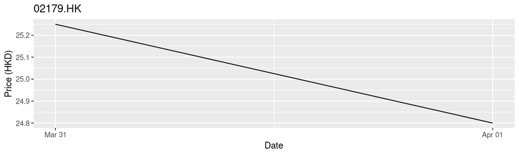

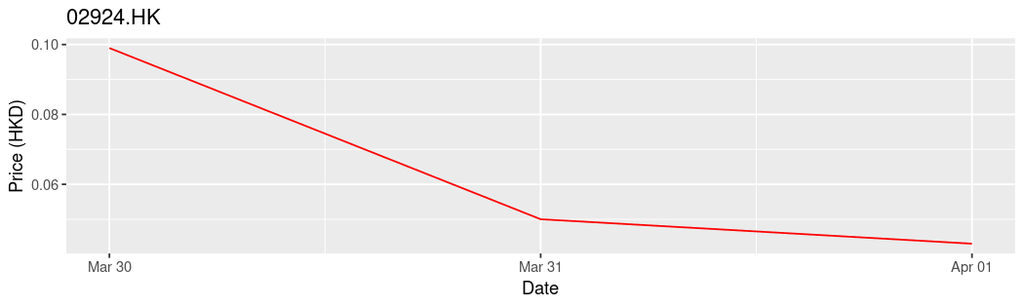

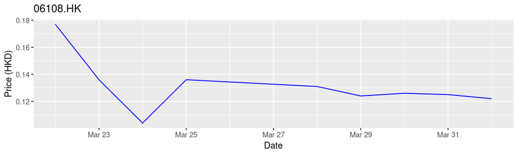

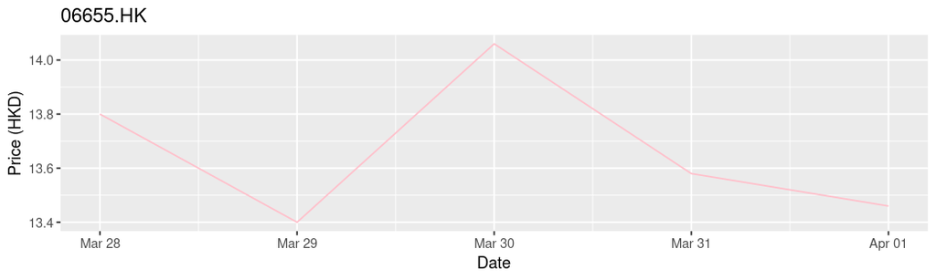

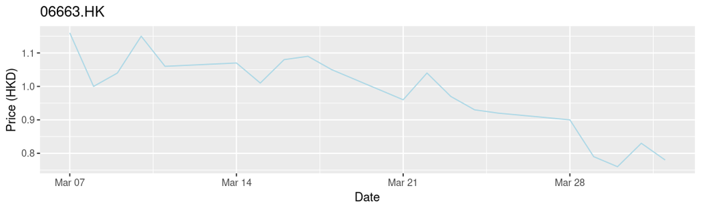

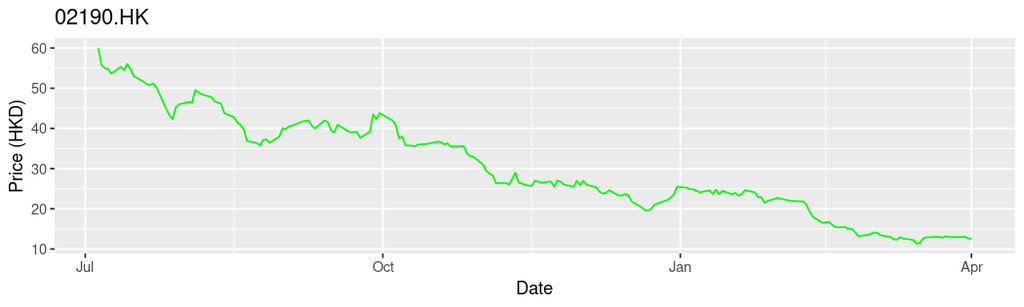

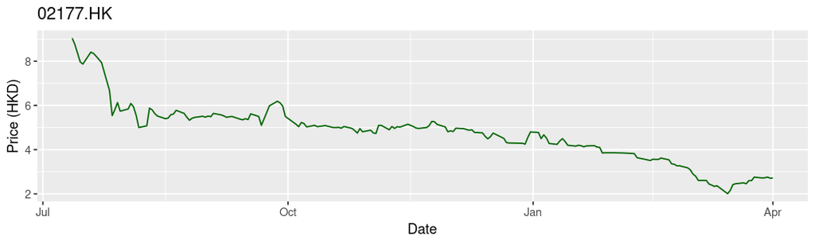

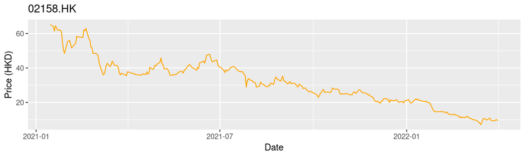

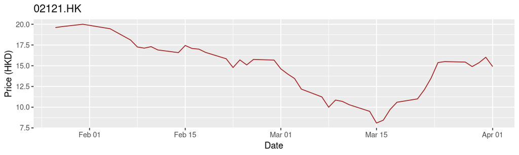

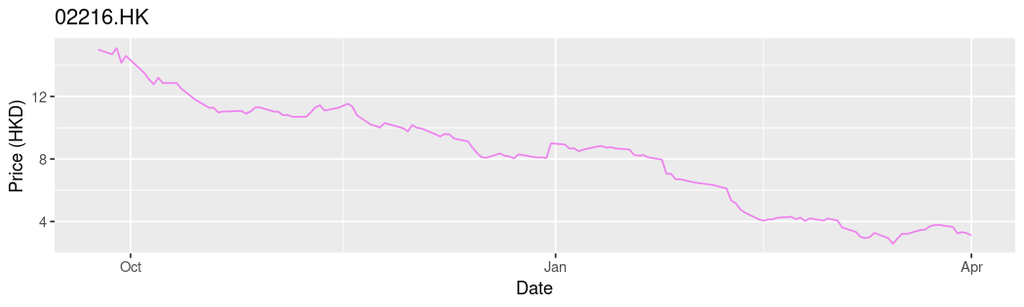

```r
# 画图
col10 <- c("black","red","blue","pink","lightblue",
           "green","darkgreen","orange","brown","violet")
c <- 1
for (i in bottom10_inc_dec_ratio){
  p <- ggplot() +
       geom_line(data=stocks_all[[i]],aes(x=date,y=close),color=col10[[c]]) +
       labs(x="Date", y="Price (HKD)") +
       ggtitle(all_symbols[[i]])
  print(p)
  c <- c+1
}
```

按涨跌日期数比值排序垫底的第11-20支股票：

```r
calc_inc_dec_ratio <- function(st){
  d1 <- diff(st$close)
  return(sum(d1>=0)/length(d1))
}
inc_dec_ratio <- to_vec(for (st in stocks_all) calc_inc_dec_ratio(st))
bottom11_20_inc_dec_ratio <- order(inc_dec_ratio)[11:20]
data.frame(
  symbol=all_symbols[bottom11_20_inc_dec_ratio],
  ratio=inc_dec_ratio[bottom11_20_inc_dec_ratio])
```

| symbol | ratio |
| --- | --- |
| 02919.HK | 0.4000000 |
| 01945.HK | 0.4096774 |
| 06998.HK | 0.4114441 |
| 06622.HK | 0.4130435 |
| 06609.HK | 0.4144737 |
| 02150.HK | 0.4148936 |
| 06628.HK | 0.4160000 |
| 06633.HK | 0.4166667 |
| 01107.HK | 0.4181818 |
| 06608.HK | 0.4193548 |

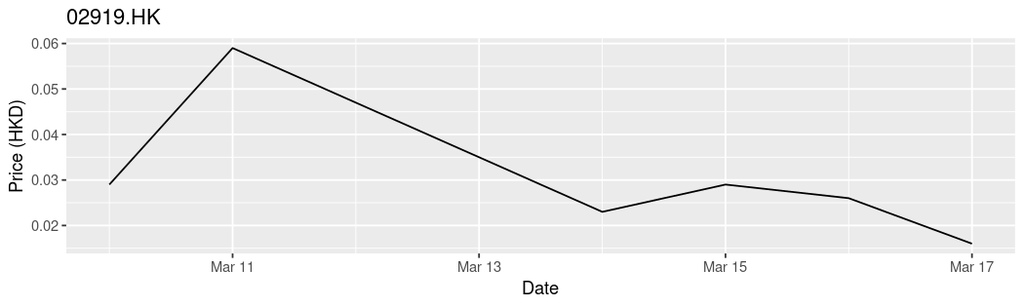

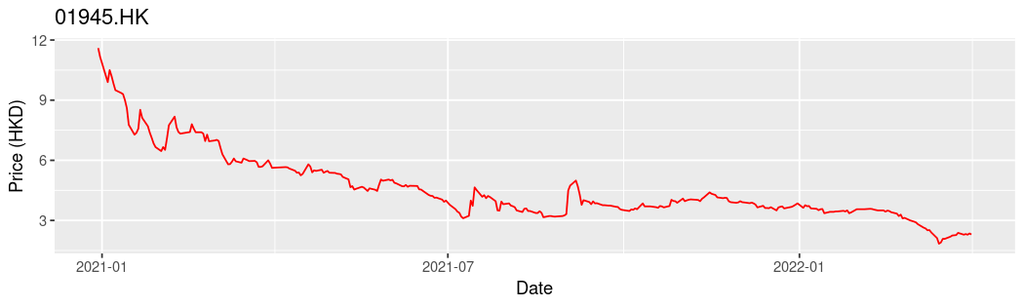

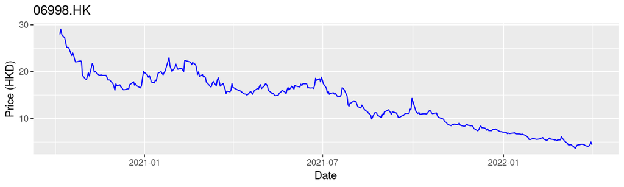

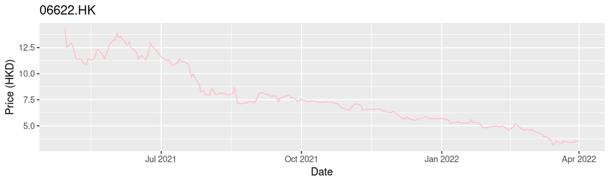

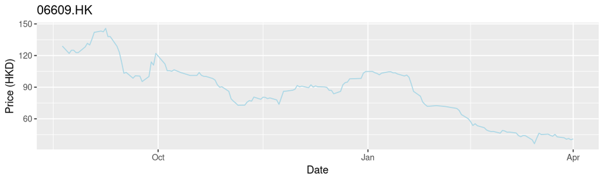

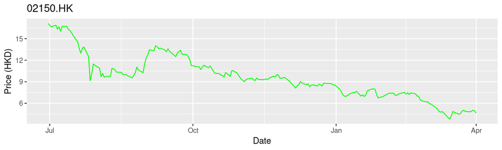

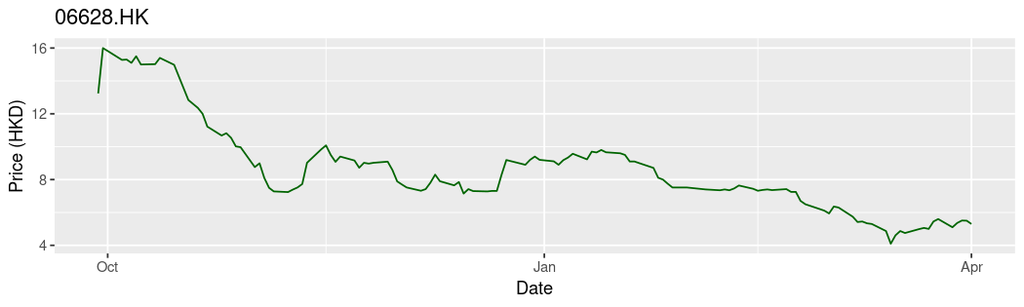

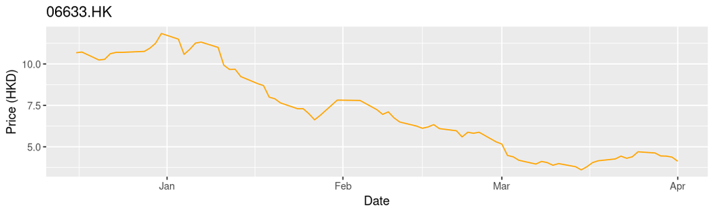

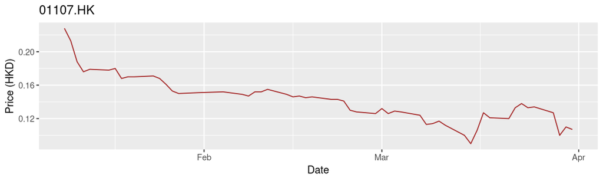

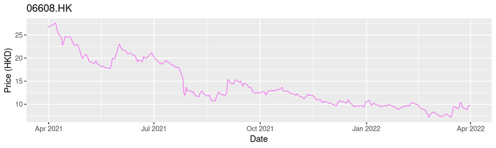

```r
# 画图
col10 <- c("black","red","blue","pink","lightblue",
           "green","darkgreen","orange","brown","violet")
c <- 1
for (i in bottom11_20_inc_dec_ratio){
  p <- ggplot() +
       geom_line(data=stocks_all[[i]],aes(x=date,y=close),color=col10[[c]]) +
       labs(x="Date", y="Price (HKD)") +
       ggtitle(all_symbols[[i]])
  print(p)
  c <- c+1
}
```

# 总结

在这篇笔记里，我们初步了解了港股股价历史数据的一些特征，以及港交所列出的全部可交易股票中的例外情况。在对资产定价模型进行统计检验时，这些例外情况必须小心地剔除。